# 小麦籽粒分类

## 包版本信息

```python
!pip freeze | grep numpy
!pip freeze | grep pandas
!pip freeze | grep scikit-learn
```

```
numpy==1.13.1
numpydoc==0.6.0
pandas==0.20.3
scikit-learn==0.19.0
```

## 数据预处理

```python
import numpy as np
import pandas as pd

## 隐藏warning信息
import warnings
warnings.filterwarnings('ignore')
```

由于数据集以`txt`文件存储，使用`Pandas`的`read_table()`函数读入数据，分隔符为`\t`。

```python
data = pd.read_table('seed.txt', sep='\t', names = ['x1', 'x2', 'x3', 'x4', 'x5', 'x6', 'x7','label'])
data.head()
```

|  | x1 | x2 | x3 | x4 | x5 | x6 | x7 | label |
| --- | --- | --- | --- | --- | --- | --- | --- | --- |
| 0 | 15.26 | 14.84 | 0.8710 | 5.763 | 3.312 | 2.221 | 5.220 | 1 |
| 1 | 14.88 | 14.57 | 0.8811 | 5.554 | 3.333 | 1.018 | 4.956 | 1 |
| 2 | 14.29 | 14.09 | 0.9050 | 5.291 | 3.337 | 2.699 | 4.825 | 1 |
| 3 | 13.84 | 13.94 | 0.8955 | 5.324 | 3.379 | 2.259 | 4.805 | 1 |
| 4 | 16.14 | 14.99 | 0.9034 | 5.658 | 3.562 | 1.355 | 5.175 | 1 |

然后，我们将`data['label']`的取值减`1`, 标签取值范围为`[0, 1, 2]`。

```python
data['label'] = data['label'] - 1
data.head()
```

|  | x1 | x2 | x3 | x4 | x5 | x6 | x7 | label |
| --- | --- | --- | --- | --- | --- | --- | --- | --- |
| 0 | 15.26 | 14.84 | 0.8710 | 5.763 | 3.312 | 2.221 | 5.220 | 0 |
| 1 | 14.88 | 14.57 | 0.8811 | 5.554 | 3.333 | 1.018 | 4.956 | 0 |
| 2 | 14.29 | 14.09 | 0.9050 | 5.291 | 3.337 | 2.699 | 4.825 | 0 |
| 3 | 13.84 | 13.94 | 0.8955 | 5.324 | 3.379 | 2.259 | 4.805 | 0 |
| 4 | 16.14 | 14.99 | 0.9034 | 5.658 | 3.562 | 1.355 | 5.175 | 0 |

```python
data.shape
```

```
(210, 8)
```

```python
# 检查有无缺失值
np.sum(data.isnull())
```

```
x1       0
x2       0
x3       0
x4       0
x5       0
x6       0
x7       0
label    0
dtype: int64
```

```python
# 标签label的取值1，2，3
data['label'].value_counts()
```

```
2    70
1    70
0    70
Name: label, dtype: int64
```

```python
class_label = np.unique(data['label'])
class_label
```

```
array([0, 1, 2])
```

```python
data.info()
```

```
<class 'pandas.core.frame.DataFrame'>
RangeIndex: 210 entries, 0 to 209
Data columns (total 8 columns):
x1       210 non-null float64
x2       210 non-null float64
x3       210 non-null float64
x4       210 non-null float64
x5       210 non-null float64
x6       210 non-null float64
x7       210 non-null float64
label    210 non-null int64
dtypes: float64(7), int64(1)
memory usage: 13.2 KB
```

```python
data.describe()
```

|  | x1 | x2 | x3 | x4 | x5 | x6 | x7 | label |
| --- | --- | --- | --- | --- | --- | --- | --- | --- |
| count | 210.000000 | 210.000000 | 210.000000 | 210.000000 | 210.000000 | 210.000000 | 210.000000 | 210.000000 |
| mean | 14.847524 | 14.559286 | 0.870999 | 5.628533 | 3.258605 | 3.700201 | 5.408071 | 1.000000 |
| std | 2.909699 | 1.305959 | 0.023629 | 0.443063 | 0.377714 | 1.503557 | 0.491480 | 0.818448 |
| min | 10.590000 | 12.410000 | 0.808100 | 4.899000 | 2.630000 | 0.765100 | 4.519000 | 0.000000 |
| 25% | 12.270000 | 13.450000 | 0.856900 | 5.262250 | 2.944000 | 2.561500 | 5.045000 | 0.000000 |
| 50% | 14.355000 | 14.320000 | 0.873450 | 5.523500 | 3.237000 | 3.599000 | 5.223000 | 1.000000 |
| 75% | 17.305000 | 15.715000 | 0.887775 | 5.979750 | 3.561750 | 4.768750 | 5.877000 | 2.000000 |
| max | 21.180000 | 17.250000 | 0.918300 | 6.675000 | 4.033000 | 8.456000 | 6.550000 | 2.000000 |

## 分类建模

### 逻辑回归

```python
from sklearn.cross_validation import cross_val_score
from sklearn.model_selection import GridSearchCV
from sklearn.model_selection import train_test_split
from sklearn.linear_model.logistic import LogisticRegression
from sklearn.metrics import classification_report, accuracy_score, confusion_matrix
```

```python
def evaluate(pred,test_y):

    import seaborn as sns
    import matplotlib.pyplot as plt
    import sklearn.metrics as metrics
    # 输出分类的准确率
    print("Accuracy: %.4f"  % (metrics.accuracy_score(test_y,pred)))

    # 输出衡量分类效果的各项指标
    print(classification_report(test_y, pred))

    # 更直观的，我们通过seaborn画出混淆矩阵
    %matplotlib inline
    plt.figure(figsize=(6,4))
    colorMetrics = metrics.confusion_matrix(test_y,pred)

    # 坐标y代表test_y，即真实的类别，坐标x代表估计出的类别pred
    sns.heatmap(colorMetrics, annot=True, fmt='d', xticklabels=[1,2,3],yticklabels=[1,2,3])
    sns.plt.show()
```

```python
## 数据准备

X = data.iloc[:, :-1]
y = data['label']
X_train, X_test, y_train, y_test = train_test_split(X, y, test_size=.25)
```

```python
lr = LogisticRegression()
param_dict = {'C': [0.001, 0.01, 0.1, 1, 10]}
gs = GridSearchCV(lr, param_grid = param_dict, scoring='accuracy')
gs.fit(X_train, y_train)
```

```
GridSearchCV(cv=None, error_score='raise',
       estimator=LogisticRegression(C=1.0, class_weight=None, dual=False, fit_intercept=True,
          intercept_scaling=1, max_iter=100, multi_class='ovr', n_jobs=1,
          penalty='l2', random_state=None, solver='liblinear', tol=0.0001,
          verbose=0, warm_start=False),
       fit_params=None, iid=True, n_jobs=1,
       param_grid={'C': [0.001, 0.01, 0.1, 1, 10]},
       pre_dispatch='2*n_jobs', refit=True, return_train_score=True,
       scoring='accuracy', verbose=0)
```

```python
pd.DataFrame(gs.cv_results_)
```

|  | mean_fit_time | mean_score_time | mean_test_score | mean_train_score | param_C | params | rank_test_score | split0_test_score | split0_train_score | split1_test_score | split1_train_score | split2_test_score | split2_train_score | std_fit_time | std_score_time | std_test_score | std_train_score |
| --- | --- | --- | --- | --- | --- | --- | --- | --- | --- | --- | --- | --- | --- | --- | --- | --- | --- |
| 0 | 0.015219 | 0.002470 | 0.382166 | 0.381955 | 0.001 | {u'C': 0.001} | 5 | 0.415094 | 0.355769 | 0.377358 | 0.375000 | 0.352941 | 0.415094 | 0.019821 | 0.003011 | 0.025520 | 0.024714 |
| 1 | 0.001227 | 0.000423 | 0.783439 | 0.764393 | 0.01 | {u'C': 0.01} | 4 | 0.754717 | 0.778846 | 0.867925 | 0.759615 | 0.725490 | 0.754717 | 0.000030 | 0.000113 | 0.061473 | 0.010414 |
| 2 | 0.002254 | 0.000865 | 0.885350 | 0.882196 | 0.1 | {u'C': 0.1} | 3 | 0.886792 | 0.884615 | 0.905660 | 0.884615 | 0.862745 | 0.877358 | 0.000599 | 0.000528 | 0.017491 | 0.003421 |
| 3 | 0.002277 | 0.000545 | 0.910828 | 0.920356 | 1 | {u'C': 1} | 2 | 0.886792 | 0.932692 | 0.962264 | 0.903846 | 0.882353 | 0.924528 | 0.000724 | 0.000129 | 0.036763 | 0.012140 |
| 4 | 0.001934 | 0.000510 | 0.949045 | 0.949020 | 10 | {u'C': 10} | 1 | 0.943396 | 0.980769 | 1.000000 | 0.913462 | 0.901961 | 0.952830 | 0.000550 | 0.000198 | 0.040093 | 0.027610 |

```python
print gs.best_params_
print gs.best_score_
```

```
{'C': 10}
0.949044585987
```

```python
lr_cls = gs.best_estimator_
score = cross_val_score(lr_cls, X_train, y_train, cv = 10, scoring = 'accuracy')
print np.mean(score)
```

```
0.942679738562
```

```
Accuracy: 0.9811
             precision    recall  f1-score   support

          0       0.94      1.00      0.97        16
          1       1.00      0.94      0.97        18
          2       1.00      1.00      1.00        19

avg / total       0.98      0.98      0.98        53
```

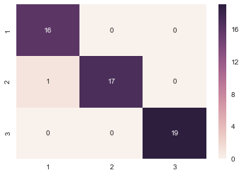

```python
evaluate(y_test, lr_cls.predict(X_test))
```

### 高斯混合模型

#### 建立模型

在本案例中，我们使用`Python`语言实现高斯混合模型。我们把实现过程分为两个部分

- 计算Expectation步

在这一步，我们计算每条数据记录$x_{n}$分属K个标签的概率$\gamma_{n}(z_{k}) = p(z_{k} = 1 \vert x_{n}, \theta)$。

```python
'''expectation_step函数

输入参数：X: 数据集
        pis: p(z = 1)的概率
        mus: 高斯分布的均值
        sigmas: 高斯分布的协方差

返回参数： $x_{n}$分属K个标签的概率矩阵

'''
def expectation_step(X, pis, mus, sigmas):

    import numpy as np
    from scipy.stats import multivariate_normal

    gammas  = np.array([value[0]*multivariate_normal(mean = value[1], cov = value[2]).pdf(X) for value in zip(pis, mus, sigmas)])
    return gammas / gammas.sum(axis = 0)
```

- 计算Maximization步

在这一步，我们以完全数据的对数极大似然函数为目标，更新参数`pis`, `mus`, `sigmas`

```python
'''maximization_step函数

输入参数：X: 数据集
        gammas：$x_{n}$分属K个标签的概率矩阵
        pis: p(z = 1)的概率
        mus: 高斯分布的均值
        sigmas: 高斯分布的协方差
'''

def maximization_step(X, gammas, pis, mus, sigmas):

    # 更新pis
    pis = gammas.sum(axis = 1)  / gammas.shape[1]


    # 更新mus
    mus = np.multiply(1.0/gammas.sum(axis = 1).reshape(-1, 1), np.dot(gammas, X))


    # 更新sigmas

    for k in range(len(sigmas)):


        centered_X = X - mus[k]

        sigmas[k] = np.dot(np.multiply(gammas[k], centered_X.T), centered_X) / gammas[k].sum()
```

更新最大似然函数的下界`lower_bound`。

```python
'''cal_lower_bound函数

输入参数：X: 数据集
        gammas：$x_{n}$分属K个标签的概率矩阵
        pis: p(z = 1)的概率
        mus: 训练得到的高斯分布的均值
        sigmas: 训练得到的高斯分布的协方差

返回参数：对数最大似然函数的下界

'''

def cal_lower_bound(X, gammas, pis, mus, sigmas):

    from scipy.stats import multivariate_normal

    lower_bound = 0

    for gamma, pi, mu, sigma in zip(gammas, pis, mus, sigmas):

        lower_bound  += np.multiply(gamma, np.log(pi*multivariate_normal(mu, sigma).pdf(X)))

    return lower_bound.sum()
```

接下来，我们实现`train_GMM`函数，计算各个高斯分布的统计特征。

```python
'''train_GMM函数

输入参数：X: 数据集
        k: 高斯分布的个数
        max_iter: 迭代的最高次数
        alpha: 最大似然函数下界收敛的阈值


返回参数：(mus, sigmas)以元组形式返回参数
        mus: 高斯分布的均值 K times d
        sigmas：高斯分布的协方差 d times d

'''
def train_GMM(X, K, max_iter, alpha):

    indicator = 0
    lower_bound = 0

    # 初始化
    N, d = X.shape
    d = d - 1

    # 初始化pi，一维数组，即 K times 1的向量
    pis = np.random.random(K)
    pis /= pis.sum()

    # 初始化mu，二维数组，即 K times d的矩阵
    #mus = np.random.random((K, d))
    mus = np.array([X[X['label'] == num].mean()[:-1] for num in range(K)])

    # 初始化sigmas  三维数组， 即长度为K，元素为 d times d 矩阵的数组
    sigmas = np.array([np.eye(d)] * K)

    X_hat = X.iloc[:,:-1].values
    while indicator <= max_iter:

        lower_bound_old = lower_bound

        # E-step
        gammas = expectation_step(X_hat, pis, mus, sigmas)

        # M-step
        maximization_step(X_hat, gammas, pis, mus, sigmas)

        # Update 下界
        lower_bound = cal_lower_bound(X_hat, gammas, pis, mus, sigmas)

        # 检查终止条件
        if abs(lower_bound - lower_bound_old) < alpha:
            print 'reach stopping criterion!'
            break

        # 更新迭代次数
        indicator += 1
    return (mus, sigmas)
```

计算高斯分布的参数之后，我们需要判定样本来自于各个分布的概率大小。也就是说将样本代入分布的密度函数，计算其密度，取最大值所在的分布作为该样本的总体分布，并将样本归属于样本所在的类。

```python
'''predict函数

输入参数： X：数据集
        mus: 各个高斯分布的均值  K time d
        sigmas: 各个高斯分布的协方差   K times 1 元素为d times d 矩阵

输出参数：数据集的各个数据记录所对应的标签(如0,1,2)

'''

def predict(X, mus, sigmas):

    from scipy.stats import multivariate_normal

    labels = np.zeros(X.shape[0])

    for index, item in enumerate(X.iloc[:,:-1].values):

        probs = [multivariate_normal(mu, sigma).pdf(item) for mu, sigma in zip(mus, sigmas)]

        labels[index] = probs.index(max(probs))

    return labels
```

#### 算法验证

我们人为生成300个分别来自3个不同高斯分布的数据样本，组成验证数据集。

```python
# 生成来自高斯混合分布的数据
# 数据集来自3个高斯分布，每个分布产生100个数据样本，数据集的维度为2
#np.random.seed(5)

mus = [[0, 4], [-2, 0], [4, 4]]

sigs = [[[3, 0], [0, 0.5]], [[1, 0], [0, 2]], [[1, 0], [0,1]]]


# 数据集X
multi_data = [np.random.multivariate_normal(mu, sig, 100) for mu, sig in zip(mus, sigs)]

data = np.vstack(multi_data)

## 数据集的类别标签为0，1，2
labels = [[value]*100 for value in range(3)]
## 把嵌套数组labels拉平
multi_labels = [y for x in labels for y in x]


# 数据集标签合并
final_data = []

for v1, v2 in zip(data, multi_labels):
    list_v1 = v1.tolist()
    list_v1.append(v2)
    final_data.append(list_v1)

##np.random.shuffle(final_data)
```

把数据集转化为`Pandas`中的`DataFrame`格式。

```python
final_data = pd.DataFrame(final_data, columns = ['x1', 'x2', 'label'])
final_data.head()
```

|  | x1 | x2 | label |
| --- | --- | --- | --- |
| 0 | -3.863865 | 5.011869 | 0 |
| 1 | 1.742150 | 3.624853 | 0 |
| 2 | 0.435850 | 5.268131 | 0 |
| 3 | 3.613564 | 3.530604 | 0 |
| 4 | 0.916746 | 4.839165 | 0 |

测试数据集准备好之后，我们把`final_data`代入函数中进行计算。

```python
mus, sigmas = train_GMM(final_data, 3, 1000, 1e-5)
```

```
reach stopping criterion!
```

```python
# 根据训练集生成的均值
mus
```

```
array([[ 0.091542  ,  3.98930488],
       [-2.07339681, -0.05747473],
       [ 3.90201609,  4.13091042]])
```

```python
# 根据训练集生成的协方差
sigmas
```

```
array([[[ 3.05429524, -0.14215967],
        [-0.14215967,  0.52348837]],

       [[ 1.11471389,  0.08816557],
        [ 0.08816557,  1.88432252]],

       [[ 1.20274147, -0.02181217],
        [-0.02181217,  1.09511199]]])
```

```python
# 在训练集上预测的标签

label_pred = predict(final_data, mus, sigmas)
print label_pred
```

```
[ 0.  0.  0.  2.  0.  0.  0.  0.  0.  0.  0.  0.  0.  0.  0.  0.  2.  0.
  0.  0.  0.  0.  0.  0.  0.  0.  0.  0.  2.  0.  0.  0.  0.  0.  0.  0.
  0.  0.  0.  0.  0.  0.  0.  0.  0.  0.  0.  2.  0.  0.  0.  0.  0.  0.
  0.  0.  0.  0.  0.  0.  2.  0.  0.  0.  0.  0.  2.  2.  0.  0.  0.  0.
  0.  0.  0.  0.  2.  0.  0.  0.  0.  0.  0.  0.  0.  2.  0.  0.  0.  0.
  2.  0.  0.  0.  0.  0.  0.  0.  0.  0.  1.  1.  1.  1.  1.  1.  1.  1.
  1.  1.  1.  1.  1.  1.  1.  1.  0.  1.  1.  1.  1.  1.  1.  1.  1.  1.
  1.  1.  1.  1.  1.  1.  1.  1.  1.  1.  1.  1.  1.  1.  1.  1.  1.  1.
  1.  1.  1.  1.  1.  1.  1.  1.  1.  1.  1.  1.  1.  1.  1.  1.  1.  1.
  1.  1.  1.  0.  1.  1.  1.  1.  1.  1.  1.  1.  1.  1.  1.  1.  1.  1.
  1.  1.  1.  1.  1.  1.  1.  1.  1.  1.  1.  1.  1.  1.  1.  1.  1.  1.
  1.  1.  2.  2.  0.  2.  2.  2.  2.  2.  2.  2.  2.  2.  2.  2.  2.  2.
  2.  2.  2.  2.  2.  2.  2.  2.  2.  2.  2.  2.  2.  2.  2.  2.  2.  2.
  2.  2.  2.  2.  2.  2.  2.  2.  2.  2.  2.  2.  2.  2.  2.  2.  2.  2.
  2.  2.  2.  2.  2.  2.  2.  2.  2.  2.  2.  2.  2.  2.  2.  2.  2.  2.
  2.  2.  2.  2.  2.  2.  2.  2.  2.  2.  2.  2.  2.  2.  2.  2.  2.  2.
  2.  2.  2.  2.  2.  2.  2.  2.  2.  2.  2.  2.]
```

```
Accuracy: 0.9567
             precision    recall  f1-score   support

          0       0.97      0.90      0.93       100
          1       1.00      0.98      0.99       100
          2       0.91      0.99      0.95       100

avg / total       0.96      0.96      0.96       300
```

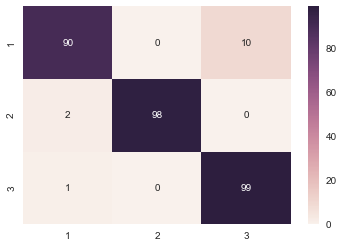

```python
## 模型评价
evaluate(label_pred, final_data['label'].values)
```

#### 使用`sklearn`的`Gaussian`函数

```python
from sklearn.mixture import GaussianMixture
```

```
Accuracy: 0.9567
             precision    recall  f1-score   support

          0       0.95      0.92      0.93       100
          1       1.00      0.97      0.98       100
          2       0.92      0.98      0.95       100

avg / total       0.96      0.96      0.96       300
```

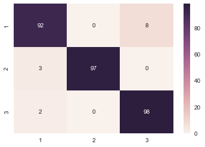

```python
gmm_model = GaussianMixture(n_components = 3, covariance_type = 'diag', init_params='random', max_iter=200)

gmm_model.means_init = np.array([final_data[final_data['label'] == num].mean(axis = 0)[:-1] for num in range(3)])

gmm_model.fit(final_data.iloc[:,:-1])

y_pred = gmm_model.predict(final_data.iloc[:,:-1])



diff = y_pred  - final_data['label'].values

evaluate(y_pred, final_data['label'].values)
```

接下来，我们查看训练得到的均值和协方差矩阵。

```python
gmm_model.means_
```

```
array([[ 0.14315648,  3.99572962],
       [-2.08035331, -0.11343775],
       [ 3.8482867 ,  4.0898108 ]])
```

```python
gmm_model.covariances_
```

```
array([[ 4.01553565,  0.61132795],
       [ 1.0545162 ,  1.44822495],
       [ 1.01247237,  1.14685908]])
```

#### 真实数据集

使用`sklearn`中的`GaussianMixture`模型，查看数据集是否适合使用高斯混合模型。

```
Accuracy: 0.8762
             precision    recall  f1-score   support

          0       0.84      0.77      0.81        70
          1       0.97      0.86      0.91        70
          2       0.83      1.00      0.91        70

avg / total       0.88      0.88      0.87       210
```

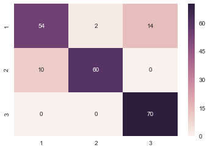

```python
gmm_model = GaussianMixture(n_components = 3, covariance_type = 'diag', init_params='random', max_iter=200)

gmm_model.means_init = np.array([data[data['label'] == num].mean(axis = 0)[:-1] for num in range(3)])

gmm_model.fit(data.iloc[:,:-1])

y_pred = gmm_model.predict(data.iloc[:,:-1])


diff = y_pred  - data['label'].values

evaluate(y_pred, data['label'].values)
```

准确率接近90%，数据集可以使用高斯混合模型来进行分类，也就是认为数据集的各个部分服从高斯分布。接下来，我们使用自定义的模型，去拟合数据集。

首先，使用数据集训练模型。我们将模型中高斯分布的个数设为`3`，迭代次数设为`2000`，终止条件的阈值设为`1e-5`。

```python
mus, sigmas = train_GMM(data, 3, 2000, 1e-5)
```

`train_GMM()`函数返回各个高斯分布component的参数值。

```python
## 均值
mus
```

```
array([[ 14.33442857,  14.29428571,   0.88007   ,   5.50805714,
          3.24462857,   2.66740286,   5.08721429],
       [ 18.33428571,  16.13571429,   0.88351714,   6.14802857,
          3.67741429,   3.6448    ,   6.0206    ],
       [ 11.87385714,  13.24785714,   0.84940857,   5.22951429,
          2.85377143,   4.7884    ,   5.1164    ]])
```

```python
## 协方差矩阵
sigmas
```

```
array([[[  9.61042610e-01,   4.49091020e-01,   3.64855457e-03,
           1.56014211e-01,   1.17141015e-01,  -1.27065732e-02,
           1.88899096e-01],
        [  4.49091020e-01,   2.25678067e-01,  -2.32360248e-04,
           8.79441594e-02,   4.61847713e-02,  -1.09081099e-02,
           1.05092971e-01],
        [  3.64855457e-03,  -2.32360248e-04,   2.53796176e-04,
          -1.24553446e-03,   1.48731511e-03,   1.09097179e-03,
          -1.30512355e-03],
        [  1.56014211e-01,   8.79441594e-02,  -1.24553446e-03,
           4.29723198e-02,   9.93728431e-03,   3.18456598e-03,
           4.96169562e-02],
        [  1.17141015e-01,   4.61847713e-02,   1.48731511e-03,
           9.93728431e-03,   2.07285674e-02,   1.02206141e-03,
           1.19468383e-02],
        [ -1.27065732e-02,  -1.09081099e-02,   1.09097179e-03,
           3.18456598e-03,   1.02206141e-03,   1.49197054e+00,
           4.91593961e-02],
        [  1.88899096e-01,   1.05092971e-01,  -1.30512355e-03,
           4.96169562e-02,   1.19468383e-02,   4.91593961e-02,
           8.22456169e-02]],

       [[  1.57851092e+00,   6.62340210e-01,   3.56424248e-03,
           2.56042627e-01,   1.71127913e-01,   7.63942476e-04,
           2.28768249e-01],
        [  6.62340210e-01,   2.95883847e-01,  -4.75500505e-04,
           1.23587613e-01,   6.15031906e-02,   1.24584162e-02,
           1.12445553e-01],
        [  3.56424248e-03,  -4.75500505e-04,   2.26310981e-04,
          -1.18668938e-03,   1.51843470e-03,  -1.93389914e-03,
          -1.28036605e-03],
        [  2.56042627e-01,   1.23587613e-01,  -1.18668938e-03,
           6.34684521e-02,   1.76146078e-02,  -8.11197909e-03,
           5.91468482e-02],
        [  1.71127913e-01,   6.15031906e-02,   1.51843470e-03,
           1.76146078e-02,   2.61011026e-02,   6.85939592e-03,
           1.34256743e-02],
        [  7.63942476e-04,   1.24584162e-02,  -1.93389914e-03,
          -8.11197909e-03,   6.85939592e-03,   1.41923766e+00,
          -1.50619323e-02],
```

[output cut: 10 more lines]

```
        [  6.98968287e-03,   3.92567483e-04,   4.48495788e-04,
          -1.26743868e-03,   2.46968621e-03,  -3.04704732e-03,
          -2.00181745e-03],
        [  5.38062306e-02,   3.96924548e-02,  -1.26743868e-03,
           2.01866081e-02,   1.52143114e-03,   3.86411654e-02,
           2.06172222e-02],
        [  8.22069311e-02,   2.63491802e-02,   2.46968621e-03,
           1.52143114e-03,   1.94984539e-02,   1.04909818e-02,
          -3.64911722e-03],
        [  4.78245130e-02,   4.63964515e-02,  -3.04704732e-03,
           3.86411654e-02,   1.04909818e-02,   1.94417811e+00,
           5.69210636e-02],
        [  3.23371835e-02,   3.34474027e-02,  -2.00181745e-03,
           2.06172222e-02,  -3.64911722e-03,   5.69210636e-02,
           3.19963703e-02]]])
```

预测数据集的标签。

```python
label_pred = predict(data, mus, sigmas)
label_pred
```

```
array([ 0.,  0.,  0.,  0.,  0.,  0.,  0.,  0.,  1.,  0.,  0.,  0.,  0.,
        0.,  0.,  0.,  0.,  0.,  0.,  2.,  0.,  0.,  0.,  2.,  0.,  0.,
        0.,  0.,  0.,  0.,  0.,  0.,  0.,  0.,  0.,  0.,  0.,  1.,  0.,
        0.,  0.,  0.,  0.,  0.,  0.,  0.,  0.,  0.,  0.,  0.,  0.,  0.,
        0.,  0.,  0.,  0.,  0.,  0.,  0.,  0.,  2.,  2.,  2.,  0.,  0.,
        0.,  0.,  0.,  0.,  2.,  1.,  1.,  1.,  1.,  1.,  1.,  1.,  1.,
        1.,  1.,  1.,  1.,  1.,  1.,  1.,  1.,  1.,  1.,  1.,  1.,  1.,
        1.,  1.,  1.,  1.,  1.,  1.,  1.,  1.,  1.,  1.,  1.,  1.,  1.,
        1.,  1.,  1.,  1.,  1.,  1.,  1.,  1.,  1.,  1.,  1.,  1.,  1.,
        1.,  1.,  1.,  1.,  1.,  1.,  1.,  1.,  1.,  1.,  1.,  1.,  1.,
        1.,  1.,  0.,  1.,  0.,  0.,  1.,  0.,  0.,  1.,  2.,  2.,  2.,
        2.,  2.,  2.,  2.,  2.,  2.,  2.,  2.,  2.,  2.,  2.,  2.,  2.,
        2.,  2.,  2.,  2.,  2.,  2.,  2.,  2.,  2.,  2.,  2.,  2.,  2.,
        2.,  2.,  2.,  2.,  2.,  2.,  2.,  2.,  2.,  2.,  2.,  2.,  2.,
        2.,  2.,  2.,  2.,  2.,  2.,  2.,  2.,  2.,  2.,  2.,  2.,  2.,
        2.,  2.,  0.,  2.,  2.,  2.,  0.,  2.,  2.,  2.,  2.,  2.,  2.,
        2.,  2.])
```

```
Accuracy: 0.9286
             precision    recall  f1-score   support

          0       0.90      0.89      0.89        70
          1       0.97      0.93      0.95        70
          2       0.92      0.97      0.94        70

avg / total       0.93      0.93      0.93       210
```

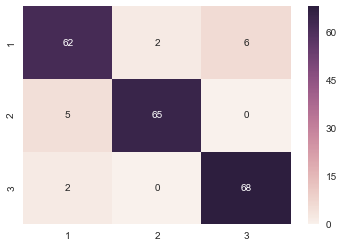

```python
evaluate(label_pred, data['label'].values)
```